# SAR11pres05

## **SAR11 Bacteria Comparative Genomics Project**

SAR11 is a group of small, carbon-oxidizing bacteria that reach a global estimated population size of 2.4×10<sup>28</sup> cells-approximately 25% of all plankton. They play a key role in the ocean’s environment.

The goal of this comparative genomics project is to find presense and absence of SAR11 genomes. The genomes of interest were obtained from NCBI database.

## Methods

- Determine goal of the project
- Decided which genomes to use and obtained them from the NCBI database
- Coding
  - Make a database
  - Get the query sequence
  - Run BLAST
  - Joining blast table with annotation table

The code was based on week 01 assignment from Fish546 Spring 23.

## Preliminary Results

Histogram for the Protein Sequences

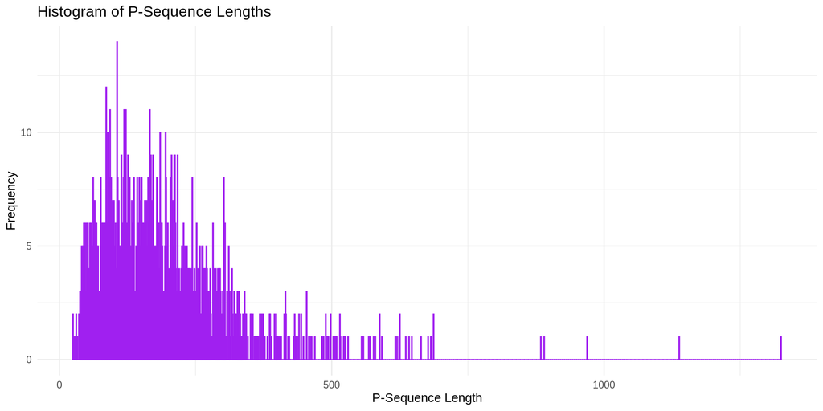

## Next Steps:

- fasta to tab-delimited for the protein sequences to finish the joining
- figure out how this process can be done for multiple protein sequences from other SAR11 sequences
  - which sequences to be chosen?
- tyding up the figures that come from other pieces of code (understanding what the code does)